# Chapter 7 Stat Rethink Practice

Anabelle Laurent

7/13/2020

Kinds of statistical error:  
*overfitting* = learning too much from the data leads to poor prediction  
*underfitting* = learning too little from the data leads to poor prediction  
*confounding*

*regularizing prior* to tell the model to not get too excited by the data  
*information criteria* or *cross-validation* to estimate predictive accuracy

R^2 is a measure of fit to sample and the more predictor variables, the higher (this is not good!).  
With overfit, the prediction can be worse than a simple model, especially if future data are not like past data.

IN sample, the most sceptical priors do worst because they learn less from the data, indeed it's sceptical! (deviance is higher than a flat prior).  
OUT of sample, the most sceptical priors predict best because it ignores irregular distractions from the sample (the deviance is smaller than a flat prior).  
If too sceptical, you learn nothing from the sample (it's bad) but some scepticism helps you for better prediction (you can always fo better than a flat prior). The regularization is useful when you don't have enough data. For multi-level, regularization is useful.

How to estimate out-of-sample deviance?  
- cross-validation: leave out one or some observations (called a fold), one at a time so it's time consuming  
- information criteria: AIC  
- WAIC: widely applicable information criterion

Deviance = general term (like Residual Sum of Squares)  
Divergence = additonal uncertainty induced by using probabilities from one distribution to describe another distribution, not reported by softwares. It can help you to compare models.  
WAIC more appropriate for Bayesian  
AIC is not appropriate for informative priors.

With large samples LOOIC,LOOCV, and WAIC perfom the same. When they disagree it means there is some highly influencial observations and there is something going on in the fit.

## E.1

3 criteria that define information entropy (E):  
- the measure should be continuous  
- E increase as the number of possible events increases  
- E should be additive.

## E.2

```r
p<-c(0.3,0.7)
-sum(p*log(p))
```

```
## [1] 0.6108643
```

## E.3

```r
p<-c(0.2,0.25,0.25,0.3)
-sum(p*log(p))
```

```
## [1] 1.376227
```

## E.4

```r
p<-c(1/3,1/3,1/3)
-sum(p*log(p))
```

```
## [1] 1.098612
```

## M.1

AIC = D_train + 2p WAIC = -2(lppd + p_WAIC)

AIC is not appropriate for informative priors while WAIC is more general and does not assume a Gaussian distribution. We need to assume gaussian distribution to transform the most general criterion into a less general one.

## M.2

Model selection = choosing the model with the lowest criterion (such as AIC, WAIC, BIC)  
Model comparison = understand how variables influence predictions, understand causal relationships

## M.3

Because the score is a sum over all the observations (see p.210), it is not averaged by the number of data

## M.4

See p. 220, adding parameters can actually reduce the effective number of parameters (=penalty in WAIC formula, it's the penalty of overfitting).

## M.5 (well explained in the YT video)

Informative priors reduce the flexibility of the model (thus they reduce overfitting). It ignores irregular distractions from the sample. But if they are too skeptical, the model will learn nothing from the data.

## M.6 (well explained in the YT video)

if priors are too skeptical, the model will learn nothing from the data. The flexibility is constrained too much -> underfitting

## H.1

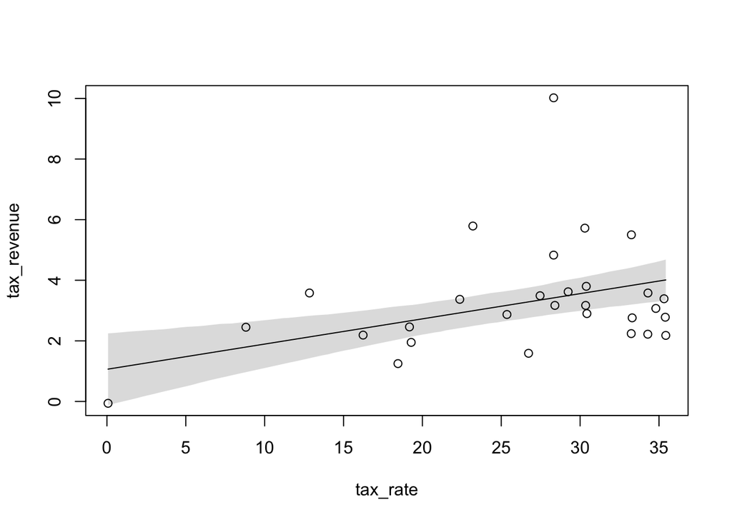

```r
data("Laffer")
d<-Laffer
m1 <- quap(
    alist(
        tax_revenue ~ dnorm( mu , exp(log_sigma) ),
        mu <- a + b*tax_rate,
        a ~ dnorm( 0.5 , 1 ),
        b ~ dnorm( 0 , 10 ),
        log_sigma ~ dnorm( 0 , 1 )
    ), data=d )

post <- extract.samples(m1)
mass_seq <- seq( from=min(d$tax_rate) , to=max(d$tax_rate) , length.out=100 )
l <- link( m1 , data=list( tax_rate=mass_seq ) )
mu <- apply( l , 2 , mean )
ci <- apply( l , 2 , PI )
plot( tax_revenue ~ tax_rate , data=d )
lines( mass_seq , mu )
shade( ci , mass_seq )
```

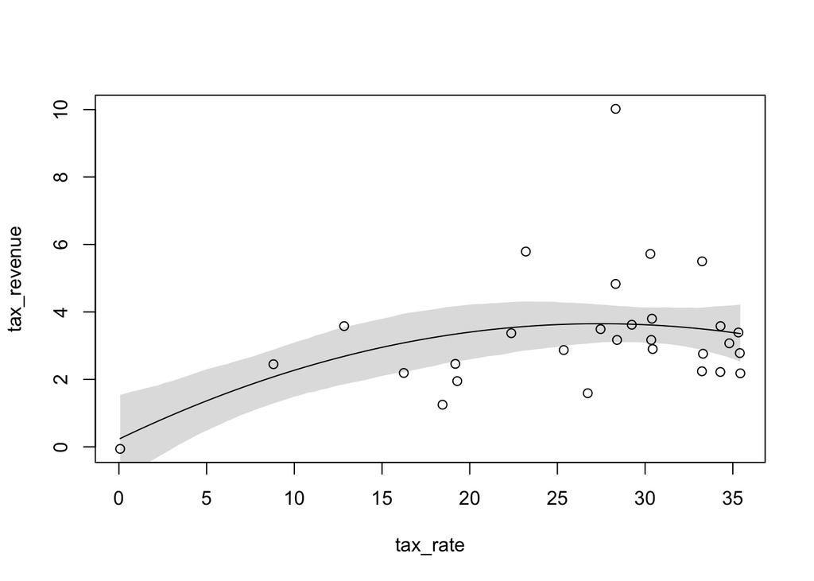

```r
m2 <- quap(
    alist(
        tax_revenue ~ dnorm( mu , exp(log_sigma) ),
        mu <- a + b[1]*tax_rate + b[2]*tax_rate^2,
        a ~ dnorm( 0.5 , 1 ),
        b ~ dnorm( 0 , 10 ),
        log_sigma ~ dnorm( 0 , 1 )
    ), data=d , start=list(b=rep(0,2)) )

post <- extract.samples(m2)
mass_seq <- seq( from=min(d$tax_rate) , to=max(d$tax_rate) , length.out=100 )
l <- link( m2 , data=list( tax_rate=mass_seq ) )
mu <- apply( l , 2 , mean )
ci <- apply( l , 2 , PI )
plot( tax_revenue ~ tax_rate , data=d )
lines( mass_seq , mu )
shade( ci , mass_seq )
```

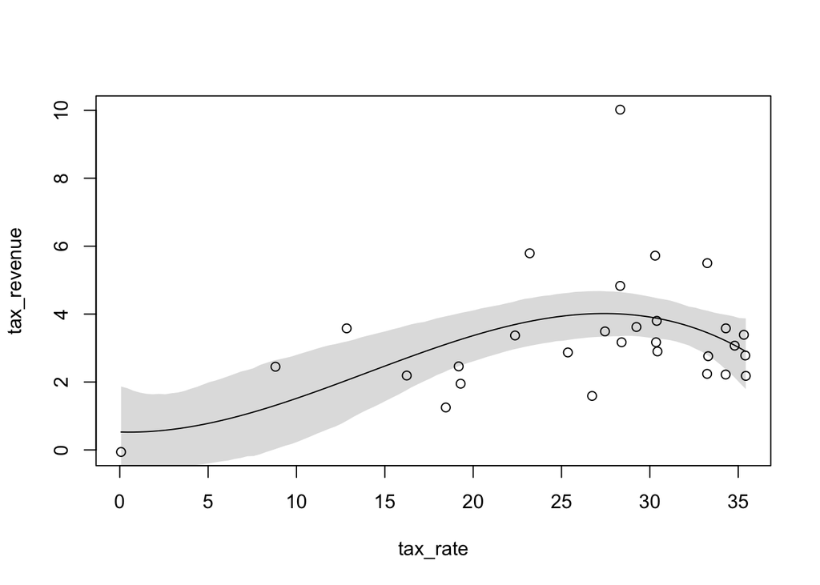

```r
m3 <- quap(
    alist(
        tax_revenue ~ dnorm( mu , exp(log_sigma) ),
        mu <- a + b[1]*tax_rate + b[2]*tax_rate^2 +
                  b[3]*tax_rate^3,
        a ~ dnorm( 0.5 , 1 ),
        b ~ dnorm( 0 , 10 ),
        log_sigma ~ dnorm( 0 , 1 )
    ), data=d , start=list(b=rep(0,3)) )

post <- extract.samples(m3)
mass_seq <- seq( from=min(d$tax_rate) , to=max(d$tax_rate) , length.out=100 )
l <- link( m3 , data=list( tax_rate=mass_seq ) )
mu <- apply( l , 2 , mean )
ci <- apply( l , 2 , PI )
plot( tax_revenue ~ tax_rate , data=d )
lines( mass_seq , mu )
shade( ci , mass_seq )
```

```r
set.seed(1)
sapply( list(m1,m2,m3) , function(m) sum(lppd(m)) )
```

```
## [1] -55.76038 -54.49488 -54.02600
```

```r
compare( m1,m2,m3, func=WAIC )
```

```
##        WAIC       SE    dWAIC      dSE    pWAIC    weight
## m2 120.8511 21.08823 0.000000       NA 5.875551 0.5291563
## m3 122.3809 21.39499 1.529765 1.910765 7.179644 0.2462633
## m1 122.5652 20.98336 1.714100 2.617404 5.425945 0.2245804
```

## H.2

```r
set.seed(24071847)
PSIS_m2 <- PSIS(m2,pointwise=TRUE)
```

```
## Some Pareto k values are very high (>1). Set pointwise=TRUE to inspect individual points.
```

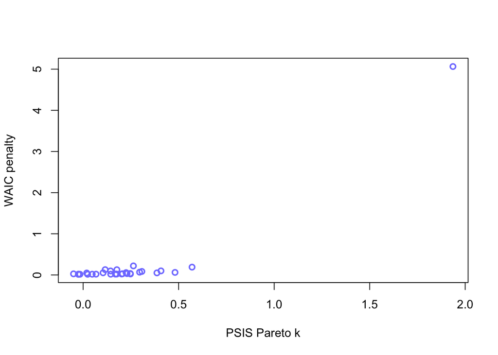

```r
set.seed(24071847)
WAIC_m2 <- WAIC(m2,pointwise=TRUE)
plot( PSIS_m2$k , WAIC_m2$penalty , xlab="PSIS Pareto k" ,
    ylab="WAIC penalty" , col=rangi2 , lwd=2 )
```

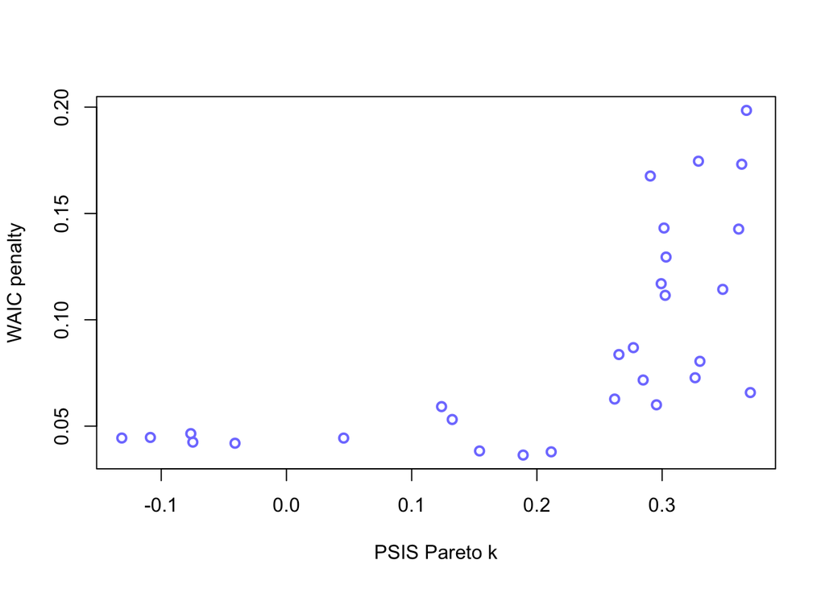

```r
m2t <- quap(
    alist(
        tax_revenue ~ dstudent( 2 , mu , sigma ) ,
        mu <-  a + b*tax_rate ,
        a ~ dnorm( 0 , 0.2 ) ,
        b~ dnorm( 0 , 0.5 ) ,
        sigma ~ dexp( 1 )
    ) , data = d )

set.seed(24071847)
PSIS_m2t <- PSIS(m2t,pointwise=TRUE)
set.seed(24071847)
WAIC_m2t <- WAIC(m2t,pointwise=TRUE)
plot( PSIS_m2t$k , WAIC_m2t$penalty , xlab="PSIS Pareto k" ,
    ylab="WAIC penalty" , col=rangi2 , lwd=2 )
```

```r
d <- sim_happiness( seed=1977 , N_years=1000 )
precis(d)
```

```
##                    mean        sd      5.5%     94.5%     histogram
## age        3.300000e+01 18.768883  4.000000 62.000000 ▇▇▇▇▇▇▇▇▇▇▇▇▇
## married    3.007692e-01  0.458769  0.000000  1.000000    ▇▁▁▁▁▁▁▁▁▃
## happiness -1.000070e-16  1.214421 -1.789474  1.789474      ▇▅▇▅▅▇▅▇
```

```r
d2 <- d[ d$age>17 , ] # only adults
d2$A <- ( d2$age - 18 ) / ( 65 - 18 )
d2$mid <- d2$married+1
m6.9 <- quap(
    alist(
        happiness ~ dnorm( mu , sigma ),
        mu <- a[mid] + bA*A,
        a[mid] ~ dnorm( 0 , 1 ),
        bA ~ dnorm( 0 , 2 ),
        sigma ~ dexp(1)
    ) , data=d2 )

m6.10 <- quap(
    alist(
        happiness ~ dnorm( mu , sigma ),
        mu <- a + bA*A,
        a ~ dnorm( 0 , 1 ),
        bA ~ dnorm( 0 , 2 ),
        sigma ~ dexp(1)
    ) , data=d2 )

set.seed(1)
sapply( list(m6.10,m6.10) , function(m) sum(lppd(m)) )
```

```
## [1] -1548.627 -1548.597
```

```r
compare( m6.9,m6.10, func=WAIC )
```

```
##           WAIC       SE    dWAIC      dSE    pWAIC       weight
## m6.9  2713.872 37.50853   0.0000       NA 3.692254 1.000000e+00
## m6.10 3101.860 27.77218 387.9879 35.38763 2.328778 5.616991e-85
```

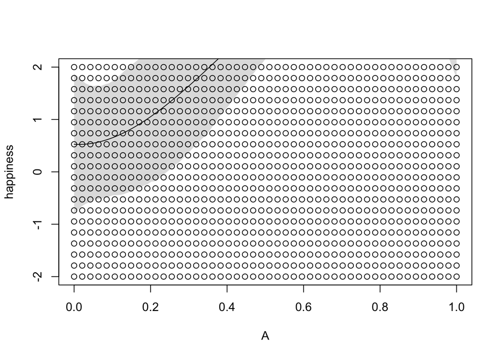

```r
post <- extract.samples(m6.9)
mass_seq <- seq( from=min(d2$A) , to=max(d2$A) , length.out=100 )
#l <- link( m6.9 , data=list( A=mass_seq ) )
mu <- apply( l , 2 , mean )
ci <- apply( l , 2 , PI )
plot( happiness ~ A , data=d2 )
lines( mass_seq , mu )
shade( ci , mass_seq )
```